# Método de Momentos: Propriedades Assintóticas

Jaqueline Lamas da Silva

30/06/2026

## Introdução

O método determina estimadores estabelecendo uma relação entre os momentos amostrais $\boldsymbol{m_n}$ e os momentos populacionais $\boldsymbol{h}(\boldsymbol\theta)$.

## Estimador de momentos

Sejam $X_1, ..., X_n$ variáveis aleatórias i.i.d com distribuição,
$$X\sim f(x,\boldsymbol{\theta}),\ \boldsymbol{\theta} \in \Theta \subset \mathbb{R}^k, k\geq1$$
Considere a seguinte função
$$\boldsymbol{g}(X) = \left[
\begin{matrix}
g_1(X) \\
\vdots \\
g_k(X)
\end{matrix}
\right]_{k\times1}.$$

Dessa forma, os momentos amostrais baseados em $g$ são:
$$\begin{align}
\boldsymbol{m_{n}} = \left[\begin{matrix}
\frac{1}{n}\sum_{i=1}^{n}g_1(X_i) \\
\vdots \\
\frac{1}{n}\sum_{i=1}^{n}g_k(X_i) \\
\end{matrix}
\right] = \left[\begin{matrix}
m_n^{(1)} \\
\vdots\\
m_n^{(k)}
\end{matrix}\right]_{k\times1}.
\end{align}$$
Em sua formulação mais tradicional $g_j(X)= X^j$.

Os momentos populacionais são obtidos da seguinte forma:
$$\boldsymbol{h(\theta)} = \left[\begin{matrix}
E_{\theta}\left[ g_1(X)\right] \\
\vdots \\
E_{\theta}\left[ g_k(X)\right] \\
\end{matrix}
\right] = \left[\begin{matrix}
h_1(\boldsymbol{\theta}) \\
\vdots\\
h_k(\boldsymbol{\theta})
\end{matrix}\right]_{k\times1}$$

Com base nisso, o estimador dos momentos $\boldsymbol{\hat{\theta}_{M}}$ é obtido pela solução das equações:
$$\boldsymbol{h(\theta)} = \boldsymbol{m_{n}}.$$

## Normalidade Assintótica

**Suposições:**

- $\mathbb{P}_{\boldsymbol{\theta}}\Vert g\Vert^2 = E_{\boldsymbol{\theta}}\left[ \sum_{j=1}^k{g_j(X)}^2\right]< \infty$;
- $h_j(\boldsymbol{\theta}) < \infty, j=1,\dots, 2k$ (caso simples $g_j(X) = X^j$);
- $\boldsymbol{H}(\boldsymbol{\theta})$ deve ter posto completo e seus elementos devem ser funções contínuas de $\boldsymbol{\theta}$.

**Teorema:**

Considerando o cenário proposto e assumindo que as suposições descritas sejam válidas, verifica-se que:

$$\boldsymbol{\sqrt{n}(\boldsymbol{\hat{\theta}}_M - \boldsymbol{\theta_0})} \xrightarrow{d} \mathcal{N}_k(\boldsymbol{0}, [\boldsymbol{H(\theta_0)}]^{-1}\boldsymbol{\Sigma}\{[\boldsymbol{H(\theta_0)}]^{-1}\}^\intercal).$$

## Normalidade Assintótica (PROVA)

Considere $\boldsymbol{\lambda} \in \mathbb{R}^k$ um vetor arbitrário, podemos definir uma sequência de variáveis aleatórias i.i.d da seguinte forma:

$$\begin{align}
U_i &= \boldsymbol{\lambda}^{\intercal}\left[\boldsymbol{g}(X_i) - \boldsymbol{h}(\boldsymbol{\theta})\right] =\\
&=\sum_{j=1}^{k}\lambda_j\left[g_j(X_i) - h_i(\boldsymbol{\theta})\right]
\end{align}$$
Não é difícil mostrar que $E_\boldsymbol{\theta}\left[U_i\right] = 0$:
$$\begin{align}
E_\boldsymbol{\theta}\left[U_i\right] &= E_\boldsymbol{\theta}\left[\boldsymbol{\lambda}^{\intercal}\left\{ \boldsymbol{g}(X_i) - \boldsymbol{h}(\boldsymbol{\theta})\right\}\right] =\\
&=\boldsymbol{\lambda}^{\intercal}\left\{E_\boldsymbol{\theta}\left[ \boldsymbol{g}(X_i) - \boldsymbol{h}(\boldsymbol{\theta})\right]\right\} =\\
&=\boldsymbol{\lambda}^{\intercal}\left\{E_\boldsymbol{\theta}\left[ \boldsymbol{g}(X_i)\right] - \boldsymbol{h}(\boldsymbol{\theta}) \right\}=\\
&=\boldsymbol{\lambda}^{\intercal}\left\{\boldsymbol{h}(\boldsymbol{\theta}) - \boldsymbol{h}(\boldsymbol{\theta}) \right\}=\\
&=\boldsymbol{\lambda}_{1\times k}^{\intercal}\left\{\mathbf{0} \right\}_{k\times 1}=\\
&=0.
\end{align}$$

Além disso, $Var_{\boldsymbol{\theta}}\left[U_i\right] = \boldsymbol{\lambda}^{\intercal} \boldsymbol{\Sigma}\boldsymbol{\lambda}$, onde $\boldsymbol{\Sigma} = Cov_{\boldsymbol{\theta}}\left[\boldsymbol{g}(X_i)\right]$

$$\begin{align}
Var_{\boldsymbol{\theta}}\left[U_i\right] &= Var_{\boldsymbol{\theta}}\left[\boldsymbol{\lambda}^{\intercal}\left\{ \boldsymbol{g}(X_i) - \boldsymbol{h}(\boldsymbol{\theta})\right\}\right] =\\
&=Var_{\boldsymbol{\theta}}\left[\boldsymbol{\lambda}^{\intercal}\boldsymbol{g}(X_i)\right]= \\
&=\boldsymbol{\lambda}^{\intercal}Cov_{\boldsymbol{\theta}}\left[\boldsymbol{g}(X_i)\right]\boldsymbol{\lambda} \\
&=\boldsymbol{\lambda}_{1\times k}^{\intercal} \boldsymbol{\Sigma}_{k\times k}\boldsymbol{\lambda}_{k\times1}.
\end{align}$$

Como as variáveis aleatórias $U_i$ são independentes e identicamente distribuídas, com média 0 e variância $\boldsymbol{\lambda}^{\intercal} \boldsymbol{\Sigma}\boldsymbol{\lambda}$, pelo TCL, temos que:

$$\frac{1}{\sqrt{n}}\sum_{i=1}^{n}U_i \xrightarrow{d} N(0, \boldsymbol{\lambda}^{\intercal} \boldsymbol{\Sigma}\boldsymbol{\lambda})$$

Temos também que
$$\begin{align}
\frac{1}{\sqrt{n}}\sum_{i=1}^{n}U_i&=\frac{1}{\sqrt{n}}\sum_{i=1}^{n}\boldsymbol{\lambda}^{\intercal}\left[\boldsymbol{g}(X_i) - \boldsymbol{h}(\boldsymbol{\theta})\right]=\\
&=\boldsymbol{\lambda}^{\intercal}\frac{1}{\sqrt{n}}\left[\sum_{i=1}^{n}\boldsymbol{g}(X_i) - n.\boldsymbol{h}(\boldsymbol{\theta})\right] =\\
&=\boldsymbol{\lambda}^{\intercal}\sqrt{n}\left[\frac{1}{n}\sum_{i=1}^{n}\boldsymbol{g}(X_i)- \boldsymbol{h}(\boldsymbol{\theta})\right] =\\
&=\boldsymbol{\lambda}^{\intercal}\sqrt{n}\left[ \boldsymbol{m_{n}} - \boldsymbol{h}(\boldsymbol{\theta})\right].
\end{align}$$
Ou seja,

$$\boldsymbol{\lambda}^{\intercal}\sqrt{n}\left[ \boldsymbol{m_{n}} - \boldsymbol{h}(\boldsymbol{\theta})\right] \xrightarrow{d} N(0,\boldsymbol{\lambda}^{\intercal} \boldsymbol{\Sigma}\boldsymbol{\lambda}).$$

#### Teorema de Cramér-Wold:

$$\boldsymbol{Y}_n \xrightarrow{d} \boldsymbol{Y} \iff \boldsymbol{\lambda}^\top \boldsymbol{Y}_n \xrightarrow{d} \boldsymbol{\lambda}^\top \boldsymbol{Y} \quad \text{para todo vetor fixo } \boldsymbol{\lambda}$$
Como $U_i$ foi definida para um $\boldsymbol{\lambda}$ qualquer e mostramos o seguinte:
$$\boldsymbol{\lambda}^{\intercal}\sqrt{n}\left[ \boldsymbol{m_{n}} - \boldsymbol{h}(\boldsymbol{\theta})\right] \xrightarrow{d} \boldsymbol{\lambda}^{\intercal}\boldsymbol{J},\quad \text{onde } \boldsymbol{J}\sim\mathcal{N}_k(\boldsymbol{0}_{k\times1},\boldsymbol{\Sigma}_{k\times k})\text{ e } \boldsymbol{\lambda}^{\intercal}\boldsymbol{J}\sim N(0,\boldsymbol{\lambda}^{\intercal} \boldsymbol{\Sigma}\boldsymbol{\lambda}).$$

**Resultado 1:**

$$\sqrt{n}\left[ \boldsymbol{m_{n}} - \boldsymbol{h}(\boldsymbol{\theta})\right] \xrightarrow{d} \boldsymbol{J}.$$

#### Expansão em série de Taylor:

Considere $\boldsymbol{u}$ um vetor em $\mathbb{R}^k$, vamos expandir a função $\boldsymbol{h}(\boldsymbol{\theta_0}+\frac{1}{\sqrt{n}}\boldsymbol{u})$ em torno de $\boldsymbol{\theta_0}$.

Para isso, considere também $\boldsymbol{H}(\boldsymbol{\theta})_{k\times k} = \frac{\partial \boldsymbol{h}(\boldsymbol{\theta})}{\partial \boldsymbol{\theta^\intercal}}$, ou seja,
$$\boldsymbol{H}(\boldsymbol{\theta})_{k\times k} = \left[\begin{matrix}
\frac{\partial h_1(\boldsymbol{\theta})}{\partial \theta_1} \frac{\partial h_1(\boldsymbol{\theta})}{\partial \theta_2} \cdots \frac{\partial h_1(\boldsymbol{\theta})}{\partial \theta_k} \\
\frac{\partial h_2(\boldsymbol{\theta})}{\partial \theta_1} \frac{\partial h_2(\boldsymbol{\theta})}{\partial \theta_2} \cdots \frac{\partial h_2(\boldsymbol{\theta})}{\partial \theta_k} \\
\vdots \quad \quad \ddots \quad \quad \vdots\\
\frac{\partial h_k(\boldsymbol{\theta})}{\partial \theta_1} \frac{\partial h_k(\boldsymbol{\theta})}{\partial \theta_2} \cdots \frac{\partial h_k(\boldsymbol{\theta})}{\partial \theta_k} \\
\end{matrix}\right].$$

Além disso, definimos $\boldsymbol{\theta^*} = \boldsymbol{\theta_0}+\frac{1}{\sqrt{n}} t.\boldsymbol{u}$, onde $0\leq t \leq1$ (entre $\boldsymbol{\theta_0}$ e $\boldsymbol{\theta_0}+\frac{1}{\sqrt{n}}\boldsymbol{u}$):

- $t=0, \boldsymbol{\theta^*}= \boldsymbol{\theta_0}$;
- $t=1, \boldsymbol{\theta^*}= \boldsymbol{\theta_0}+\frac{1}{\sqrt{n}}\boldsymbol{u}$;
- $\boldsymbol{\theta^*} \xrightarrow{n\to \infty} \boldsymbol{\theta_0}$.

Com isso, temos que:
$$\boldsymbol{h}(\boldsymbol{\theta_0}+\frac{1}{\sqrt{n}}\boldsymbol{u}) = \boldsymbol{h(\theta)}\Big{|}_{\boldsymbol{\theta}=\boldsymbol{\theta_0}} + \boldsymbol{H(\theta)}\Big{|}_{\boldsymbol{\theta}=\boldsymbol{\theta}^*}(\boldsymbol{\theta_0}+\frac{1}{\sqrt{n}}\boldsymbol{u} - \boldsymbol{\theta_0})$$
Vamos adicionar e subtrair $\boldsymbol{H(\theta_0)}(\boldsymbol{\theta_0}+\frac{1}{\sqrt{n}}\boldsymbol{u}-\boldsymbol{\theta_0})$

$$\small{
\begin{align}
\boldsymbol{h}(\boldsymbol{\theta_0}+\frac{1}{\sqrt{n}}\boldsymbol{u}) &= \boldsymbol{h(\theta_0)} + \boldsymbol{H(\theta^*)}(\boldsymbol{\theta_0}+\frac{1}{\sqrt{n}}\boldsymbol{u} - \boldsymbol{\theta_0}) + \boldsymbol{H(\theta_0)}(\boldsymbol{\theta_0}+\frac{1}{\sqrt{n}}\boldsymbol{u}-\boldsymbol{\theta_0}) - \boldsymbol{H(\theta_0)}(\boldsymbol{\theta_0}+\frac{1}{\sqrt{n}}\boldsymbol{u}-\boldsymbol{\theta_0})=\\
&=\boldsymbol{h(\theta_0)} + \boldsymbol{H(\theta^*)}(\frac{1}{\sqrt{n}}\boldsymbol{u} ) + \boldsymbol{H(\theta_0)}(\frac{1}{\sqrt{n}}\boldsymbol{u})- \boldsymbol{H(\theta_0)}(\frac{1}{\sqrt{n}}\boldsymbol{u})=\\
&=\boldsymbol{h(\theta_0)} + \boldsymbol{H(\theta^*)}(\frac{1}{\sqrt{n}}\boldsymbol{u} ) + \boldsymbol{H(\theta_0)}(\frac{1}{\sqrt{n}}\boldsymbol{u})- \boldsymbol{H(\theta_0)}(\frac{1}{\sqrt{n}}\boldsymbol{u})=\\
&=\boldsymbol{h(\theta_0)} + \boldsymbol{H(\theta_0)}(\frac{1}{\sqrt{n}}\boldsymbol{u}) + \left[ \boldsymbol{H(\theta^*)} - \boldsymbol{H(\theta_0)}\right](\frac{1}{\sqrt{n}}\boldsymbol{u}).
\end{align}
}$$
Como $\boldsymbol{\theta^*} \xrightarrow{n\to \infty} \boldsymbol{\theta_0}$ e $\boldsymbol{H(\theta^*)} \xrightarrow{n\to \infty} \boldsymbol{H(\theta_0)}$, então

$$\boldsymbol{h}(\boldsymbol{\theta_0}+\frac{1}{\sqrt{n}}\boldsymbol{u}) =\boldsymbol{h(\theta_0)} + \boldsymbol{H(\theta_0)}(\frac{1}{\sqrt{n}}\boldsymbol{u}) + o(1).$$

Após algumas manipulações, temos
$$\boldsymbol{h}(\boldsymbol{\theta_0}+\frac{1}{\sqrt{n}}\boldsymbol{u}) - \boldsymbol{h(\theta_0)} = \frac{1}{\sqrt{n}} \boldsymbol{H(\theta_0)}.\boldsymbol{u} + o(1)$$

$$\sqrt{n}\left[\boldsymbol{h}(\boldsymbol{\theta_0}+\frac{1}{\sqrt{n}}\boldsymbol{u}) - \boldsymbol{h(\theta_0)}\right] = \boldsymbol{H(\theta_0)}.\boldsymbol{u} + o(1)$$
Se considerarmos $\boldsymbol{u}=\sqrt{n}(\boldsymbol{\hat{\theta}}_M - \boldsymbol{\theta_0})$ então $\boldsymbol{h}(\boldsymbol{\theta_0}+\frac{1}{\sqrt{n}}\boldsymbol{u}) = \boldsymbol{h}(\boldsymbol{\hat{\theta}_M})=\boldsymbol{m_n}$.

Com isso,
$$\sqrt{n}\left[\boldsymbol{m_n} - \boldsymbol{h(\theta_0)}\right] = \boldsymbol{H(\theta_0)}.\boldsymbol{\sqrt{n}(\boldsymbol{\hat{\theta}}_M - \boldsymbol{\theta_0})} + o_p(1).$$
$$\sqrt{n} \boldsymbol{[H(\theta_0)]^{-1}}\left[\boldsymbol{m_n} - \boldsymbol{h(\theta_0)}\right] = \boldsymbol{\sqrt{n}(\boldsymbol{\hat{\theta}}_M - \boldsymbol{\theta_0})} + o_p(1).$$

Pelo *Resultado 1* podemos concluir que:
$$\boldsymbol{\sqrt{n}(\boldsymbol{\hat{\theta}}_M - \boldsymbol{\theta_0})} \xrightarrow{d} \mathcal{N}_k(\boldsymbol{0}, [\boldsymbol{H(\theta_0)}]^{-1}\boldsymbol{\Sigma}\{[\boldsymbol{H(\theta_0)}]^{-1}\}^\intercal).$$

## Método Delta Generalizado

Voltando ao resultado obtido anteriormente,
$$\sqrt{n}\left[ \boldsymbol{m_{n}} - \boldsymbol{h}(\boldsymbol{\theta})\right] \xrightarrow{d} \mathcal{N}_k(\boldsymbol{0}_{k\times1},\boldsymbol{\Sigma}_{k\times k}).$$
Recorde que $\boldsymbol{m_n}=\boldsymbol{h}(\boldsymbol{\hat\theta_M})$, com isso,

$$\sqrt{n}\left[ \boldsymbol{h}(\boldsymbol{\hat\theta_M}) - \boldsymbol{h}(\boldsymbol{\theta})\right] \xrightarrow{d} \mathcal{N}_k(\boldsymbol{0},\boldsymbol{\Sigma}).$$
Seja $\boldsymbol{h}^{-1}$ a função inversa. A matriz jacobiana de $\boldsymbol{h}^{-1}$, pelo Teorema da Função Inversa é a matriz inversa da jacobiana da função $\boldsymbol{h}(\boldsymbol{\theta})$, ou seja, é igual a $[\boldsymbol{H(\theta)}]^{-1}$. Portanto, podemos aplicar o Método Delta Generalizado para dizer que:
$$\boldsymbol{\sqrt{n}(\boldsymbol{\hat{\theta}}_M - \boldsymbol{\theta})} \xrightarrow{d} \mathcal{N}_k(\boldsymbol{0}, [\boldsymbol{H(\theta)}]^{-1}\boldsymbol{\Sigma}\{[\boldsymbol{H(\theta)}]^{-1}\}^\intercal).$$
Desse modo, alcançamos o resultado de normalidade assintótica por dois caminhos diferentes.

## Exemplo

Sejam $X_1, ..., X_n$ variáveis aleatórias i.i.d com distribuição,
$$X\sim Beta(\alpha,\beta),\ \boldsymbol{\theta}=(\alpha, \beta)^\intercal \in \Theta = \{ (\alpha, \beta) \in \mathbb{R}^2 : \alpha > 0, \beta > 0 \}$$
$$\boldsymbol{g}(X) = \left[
\begin{matrix}
X \\
X^2
\end{matrix}
\right]_{2\times1}$$
$$\begin{align}
\boldsymbol{m_{n}} = \left[\begin{matrix}
\frac{1}{n}\sum_{i=1}^{n}X_i \\
\frac{1}{n}\sum_{i=1}^{n}X_i^2 \\
\end{matrix}
\right]
\end{align}$$
$$\boldsymbol{h(\theta)} = \left[\begin{matrix}
E_{\theta}\left[ X\right] \\
E_{\theta}\left[ X^2\right] \\
\end{matrix}
\right] = \left[\begin{matrix}
\frac{\alpha}{\alpha+\beta} \\
\frac{\alpha}{\alpha+\beta}.\frac{\alpha+1}{\alpha+\beta+1}
\end{matrix}\right]$$
Os momentos teóricos de ordem $k$ de uma variável aleatória $X$ com distribuição $\text{Beta}(\alpha, \beta)$ é dado pela seguinte fórmula:
$$E[X^k] = \frac{\Gamma(\alpha + k)\Gamma(\alpha + \beta)}{\Gamma(\alpha)\Gamma(\alpha + \beta + k)}.$$

Resolvendo o sistema de equações:
$$\boldsymbol{h}(\boldsymbol{\theta})=\boldsymbol{m_{n}}$$

$$\begin{cases}
\frac{\alpha}{\alpha + \beta} = \frac{1}{n}\sum_{i=1}^{n}X_i \\
\frac{\alpha(\alpha + 1)}{(\alpha + \beta)(\alpha + \beta + 1)}=
\frac{1}{n}\sum_{i=1}^{n}X_i^2 \\
\end{cases},$$
temos que $\boldsymbol{\hat{\theta}_M}$ é $(\hat\alpha,\hat\beta)^\intercal$ onde
$$\small{
\hat\alpha= \frac{\frac{1}{n}\sum_{i=1}^{n}X_i .\left(\frac{1}{n}\sum_{i=1}^{n}X_i - \frac{1}{n}\sum_{i=1}^{n}X_i^2 \right)}{\frac{1}{n}\sum_{i=1}^{n}X_i^2 - [\frac{1}{n}\sum_{i=1}^{n}X_i]^2} \quad \text{e} \quad
\hat\beta=\frac{\left(1-\frac{1}{n}\sum_{i=1}^{n}X_i\right) .\left(\frac{1}{n}\sum_{i=1}^{n}X_i - \frac{1}{n}\sum_{i=1}^{n}X_i^2 \right)}{\frac{1}{n}\sum_{i=1}^{n}X_i^2 - [\frac{1}{n}\sum_{i=1}^{n}X_i]^2}.}$$
O resultado assintótico nos diz que:
$$\boldsymbol{\sqrt{n}(\boldsymbol{\hat{\theta}}_M - \boldsymbol{\theta})} \xrightarrow{d} \mathcal{N}_2(\boldsymbol{0}, [\boldsymbol{H(\theta)}]^{-1}\boldsymbol{\Sigma}\{[\boldsymbol{H(\theta)}]^{-1}\}^\intercal).$$
onde $\boldsymbol{\Sigma}=Cov_\boldsymbol{\theta}(\boldsymbol{g}(X))$.

$$\boldsymbol{\Sigma} = \begin{bmatrix}
E_\boldsymbol{\theta}[X^2]-\left\{ E_{\boldsymbol{\theta}}[X]\right\}^2 \quad\quad\quad E_\boldsymbol{\theta}[X^3]-E_{\boldsymbol{\theta}}[X^2].E_{\boldsymbol{\theta}}[X] \\ \\
E_\boldsymbol{\theta}[X^3]-E_{\boldsymbol{\theta}}[X^2].E_{\boldsymbol{\theta}}[X] \quad \quad E_\boldsymbol{\theta}[X^4]-\left\{ E_{\boldsymbol{\theta}}[X^2]\right\}^2
\end{bmatrix},$$

isto é
$$\Tiny{
\boldsymbol{\Sigma} = \begin{bmatrix}
\dfrac{\alpha(\alpha + 1)}{(\alpha + \beta)(\alpha + \beta + 1)} - \left( \dfrac{\alpha}{\alpha + \beta} \right)^2 & \dfrac{\alpha(\alpha + 1)(\alpha + 2)}{(\alpha + \beta)(\alpha + \beta + 1)(\alpha + \beta + 2)} - \left( \dfrac{\alpha}{\alpha + \beta} \right) \left( \dfrac{\alpha(\alpha + 1)}{(\alpha + \beta)(\alpha + \beta + 1)} \right) \\ \\
\dfrac{\alpha(\alpha + 1)(\alpha + 2)}{(\alpha + \beta)(\alpha + \beta + 1)(\alpha + \beta + 2)} - \left( \dfrac{\alpha}{\alpha + \beta} \right) \left( \dfrac{\alpha(\alpha + 1)}{(\alpha + \beta)(\alpha + \beta + 1)} \right) & \dfrac{\alpha(\alpha + 1)(\alpha + 2)(\alpha + 3)}{(\alpha + \beta)(\alpha + \beta + 1)(\alpha + \beta + 2)(\alpha + \beta + 3)} - \left( \dfrac{\alpha(\alpha + 1)}{(\alpha + \beta)(\alpha + \beta + 1)} \right)^2
\end{bmatrix}.}$$

## Simulação

Amostras geradas pela distribução
$$X\sim Beta(2,3).$$

**Código**

```r
set.seed(123)
theta.verd<-c(2,3)
sizes<-c(20,30,80,200,500)
gera<-function(n) {replicate(1000, rbeta(n, shape1 = theta.verd[1], shape2 = theta.verd[2]))}
amostras<-sapply(sizes,gera)
# Matriz H(theta)
matriz.H<-function(alfa, beta)
{
  H<-matrix(0,nrow = 2,ncol=2)
  H[1,1]<-beta/(alfa+beta)^2
  H[1,2]<-(-alfa)/(alfa+beta)^2
  H[2,1]<-beta*(2*alfa*beta+2*alfa^2+2*alfa+beta+1)/( (alfa+beta+1)*(alfa+beta) )^2
  H[2,2]<-( (-alfa)*(alfa+1)*(2*beta+2*alfa+1) )/( (alfa+beta+1)*(alfa+beta) )^2
  return(H)
}
H<-matriz.H(alfa=2,beta=3)
H.inversa<-solve(H)
```

**Código**

```r
matriz.Sigma <- function(alfa, beta)
{
  Sigma <- matrix(0, 2, 2)
  Sigma[1,1] <- (alfa * (alfa + 1)) / ((alfa + beta) * (alfa + beta + 1)) -
                (alfa / (alfa + beta))^2
  Sigma[1,2] <- (alfa * (alfa + 1) * (alfa + 2)) / ((alfa + beta) * (alfa + beta + 1) * (alfa + beta + 2)) -
                (alfa / (alfa + beta)) * ((alfa * (alfa + 1)) / ((alfa + beta) * (alfa + beta + 1)))
  Sigma[2,1] <- Sigma[1,2] # A matriz é simétrica
  Sigma[2,2] <- (alfa * (alfa + 1) * (alfa + 2) * (alfa + 3)) / ((alfa + beta) * (alfa + beta + 1) * (alfa + beta + 2) * (alfa + beta + 3)) -
                ((alfa * (alfa + 1)) / ((alfa + beta) * (alfa + beta + 1)))^2
  return(Sigma)
}
Sigma<-matriz.Sigma(2,3)

# [H'(θ)]Σt([H'(θ)]) / n é a variância teórica

n.var.teorica<-( H.inversa%*%Sigma%*%t(H.inversa) )
```

**Código**

```r
estimador.momentos<-function(i)
{
  amostra=amostras[[i]]
  n<-dim(amostra)[1]
  X.barra<-apply(amostra,2,mean)
  X.barra.2<-apply(amostra^2, 2,mean)

  # Estimador
  alfa.hat<-X.barra*(X.barra - X.barra.2)/(X.barra.2 - (X.barra^2))
  beta.hat<-(1-X.barra)*(X.barra - X.barra.2)/(X.barra.2 - (X.barra^2))

  # Variância empírica
  sd.alfa<-sd(alfa.hat)
  sd.beta<-sd(beta.hat)

  # Variancia teórica
  ep.alfa<-sqrt(n.var.teorica[1,1]/n)
  ep.beta<-sqrt(n.var.teorica[2,2]/n)

  return(list(alfa=mean(alfa.hat), sd.a=sd.alfa,ep.a=ep.alfa, beta=mean(beta.hat), sd.b=sd.beta, ep.b=ep.beta, alfas=alfa.hat, betas=beta.hat))

}
```

Tabela 1: Média das estimativas, erro padrão e erro padrão teórico para cada tamanho de amostra

|  | $\theta$ | n=20 $\hat{\theta}$ | n=20 sd | n=20 ep | n=30 $\hat{\theta}$ | n=30 sd | n=30 ep | n=80 $\hat{\theta}$ | n=80 sd | n=80 ep | n=200 $\hat{\theta}$ | n=200 sd | n=200 ep | n=500 $\hat{\theta}$ | n=500 sd | n=500 ep |
| --- | --- | --- | --- | --- | --- | --- | --- | --- | --- | --- | --- | --- | --- | --- | --- | --- |
| $\alpha$ | 2 | 2.285 | 0.864 | 0.627 | 2.175 | 0.592 | 0.512 | 2.065 | 0.333 | 0.313 | 2.025 | 0.202 | 0.198 | 2.010 | 0.124 | 0.125 |
| $\beta$ | 3 | 3.479 | 1.378 | 0.964 | 3.271 | 0.918 | 0.787 | 3.093 | 0.504 | 0.482 | 3.040 | 0.305 | 0.305 | 3.016 | 0.198 | 0.193 |

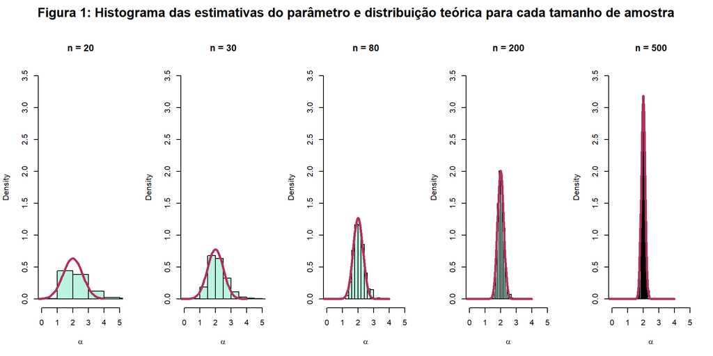

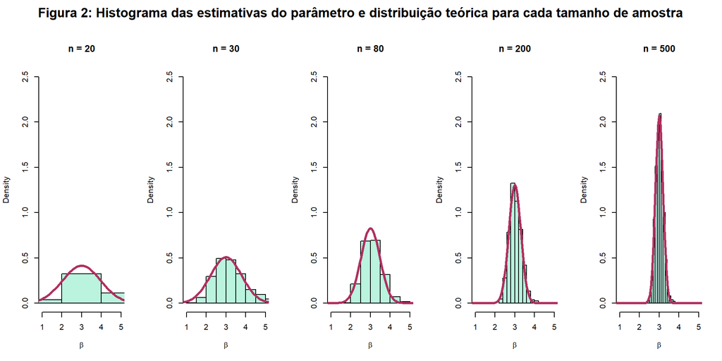

## Referências

Leite, J. G., & Singer, J. M. (1989). *Métodos assintóticos em estatística: fundamentos e aplicações*.

Sen, P. K., Singer, J. M., & Pedroso-de-Lima, A. C. (2010). *From Finite Sample to Asymptotic Methods in Statistics*. Cambridge University Press.

Van der Vaart, A. W. (1998). *Asymptotic Statistics*. Cambridge University Press.

[figure not shown]

Teoria Assintótica (MAE5917) - IME/USP